# 06_graphically_supported_hypotheses

2025-07-29

# Tutorial Exercises

## Section 01: Color Guidelines

Best practices when using color for data visualizations:

- Avoid having too many colors for categorical data
- Use color only when it actually adds meaning to the plot

## Section 02: Correlation and Causation

```r
# 1. Reverse causality: False - Correlation doesn't imply direction
# 2. If A causes B and C: False - B and C may correlate but not cause each other
# 3. If A precedes B: False - Temporal precedence ≠ causation
# 4. Causation implies association: True - But not necessarily linear
```

## Section 03: Effect of a Third Variable

### 1. Coffee and Datavizitis Association

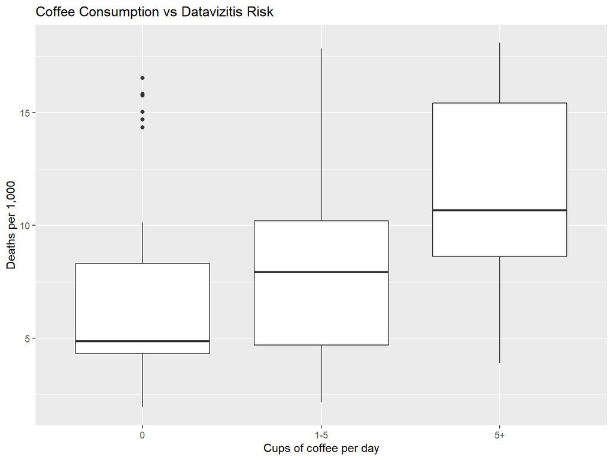

```r
coffee_dt <- fread("../data/coffee_sim.csv")
ggplot(coffee_dt, aes(coffee_cups_per_day, datavizitis_risk)) +
  geom_boxplot() +
  labs(x = "Cups of coffee per day", y = "Deaths per 1,000",
       title = "Coffee Consumption vs Datavizitis Risk")
```

### 2. Investigating Third Variables

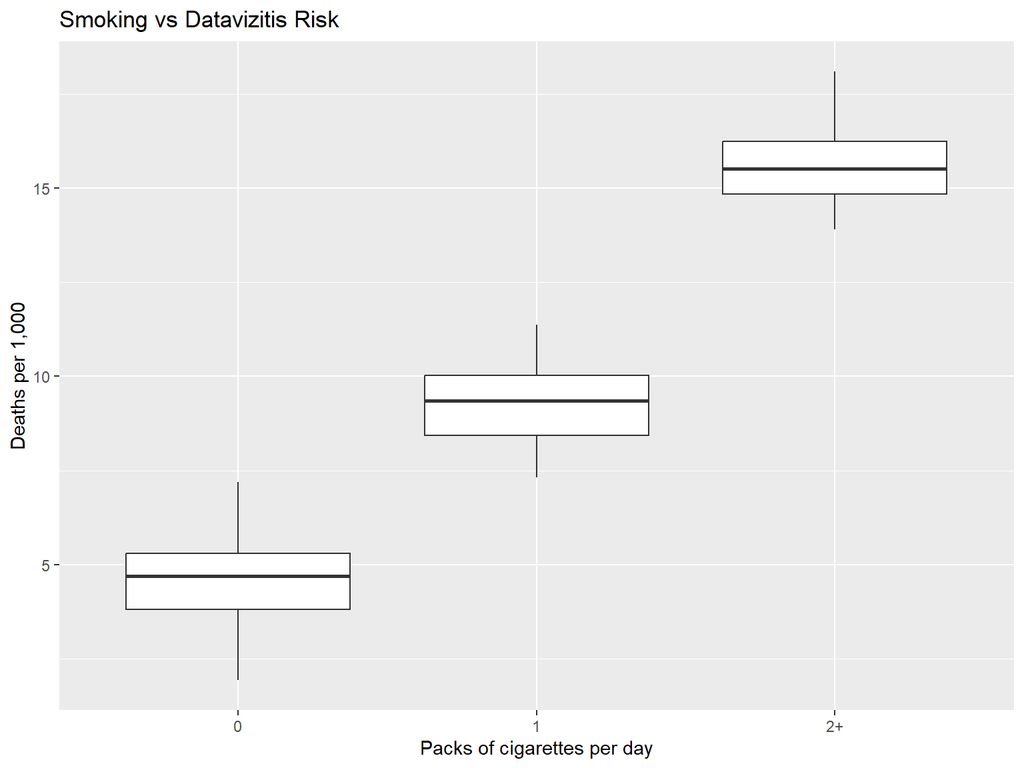

```r
# Smoking vs Datavizitis
ggplot(coffee_dt, aes(packs_cigarettes_per_day, datavizitis_risk)) +
  geom_boxplot() +
  labs(x = "Packs of cigarettes per day", y = "Deaths per 1,000",
       title = "Smoking vs Datavizitis Risk")
```

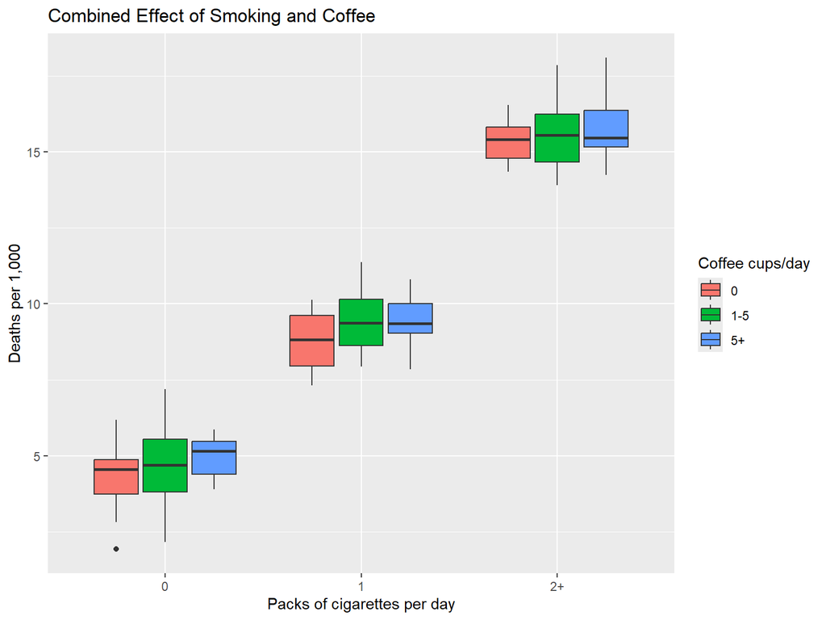

```r
# Combined effect
ggplot(coffee_dt, aes(packs_cigarettes_per_day, datavizitis_risk,
                      fill = coffee_cups_per_day)) +
  geom_boxplot() +
  labs(x = "Packs of cigarettes per day", y = "Deaths per 1,000",
       fill = "Coffee cups/day",
       title = "Combined Effect of Smoking and Coffee")
```

### 3. Causal Diagram Interpretation

Possible causal relationships:

- Smoking → Coffee consumption (common cause)
- Smoking → Datavizitis risk
- Coffee consumption has no direct effect on datavizitis

## Section 04: Visualization Guidelines

### 1. Improved Visualization

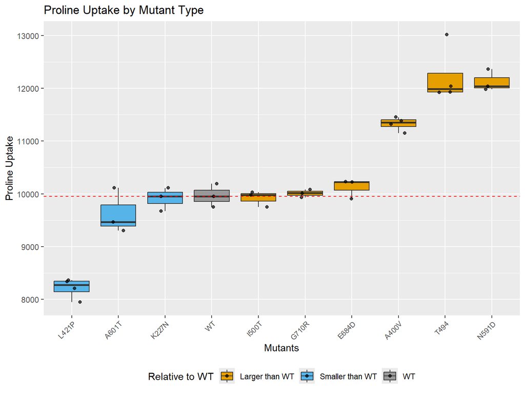

```r
# Simulate data
dt <- data.table(
  pro_uptake = c(rnorm(3, 10100, 300), rnorm(4, 12100, 300),
  rnorm(3, 9850, 300), rnorm(4, 11100, 300),
  rnorm(4, 8300, 300), rnorm(3, 10050, 300),
  rnorm(3, 12000, 300), rnorm(3, 10020, 300),
  rnorm(3, 10080, 300), rnorm(3, 10070, 300)),
  mutants = c(rep("WT", 3), rep("T494", 4), rep("K227N", 3), rep("A400V", 4),
              rep("L421P", 4), rep("I500T", 3), rep("N591D", 3),
              rep("A601T", 3), rep("E684D", 3), rep("G710R", 3))
)

# Calculate medians and sort
dt[, median_per_mut := median(pro_uptake), by = mutants]
wt_med <- unique(dt[mutants == "WT", median_per_mut])
dt[, rel_to_wt := ifelse(median_per_mut < wt_med, "Smaller than WT",
                         ifelse(median_per_mut > wt_med, "Larger than WT", "WT"))]
dt[, mutants := factor(mutants, levels = unique(dt[order(median_per_mut), mutants]))]

# Create plot
ggplot(dt, aes(mutants, pro_uptake, fill = rel_to_wt)) +
  geom_boxplot(outlier.shape = NA) +
  geom_jitter(width = 0.2, size = 1.5, alpha = 0.7) +
  geom_hline(yintercept = wt_med, linetype = "dashed", color = "red") +
  labs(y = "Proline Uptake", x = "Mutants",
       title = "Proline Uptake by Mutant Type") +
  scale_fill_manual(values = c("Larger than WT" = "#E69F00",
                               "Smaller than WT" = "#56B4E9",
                               "WT" = "#999999")) +
  theme(axis.text.x = element_text(angle = 45, hjust = 1, size = 8),
        legend.position = "bottom") +
  guides(fill = guide_legend(title = "Relative to WT"))
```

## Homework Exercises

### Section 05: COVID-19 Fatality Rates

#### 1. Load and Visualize Data

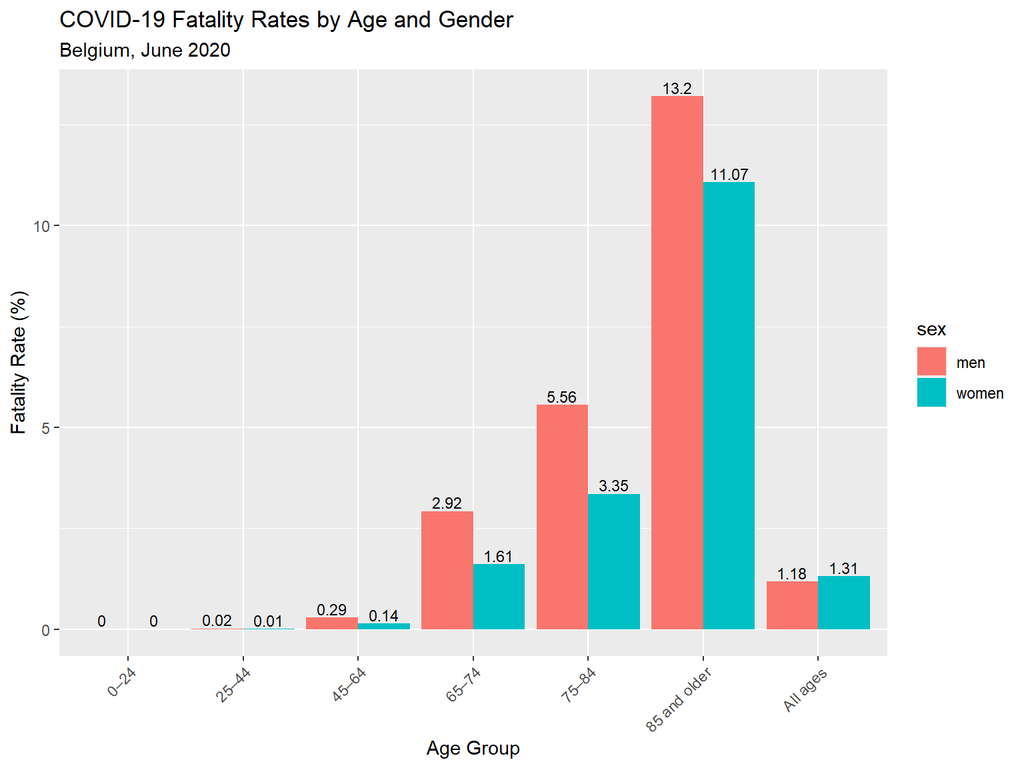

```r
fatality_dt <- fread('../data/belgium_infection_fatality_rate_june2020.csv')
fatality_long <- melt(fatality_dt, id.vars = "age_group",
                      value.name = "fatality_rate", variable.name = "sex")

# Plot
ggplot(fatality_long, aes(age_group, fatality_rate, fill = sex)) +
  geom_col(position = "dodge") +
  geom_text(aes(label = fatality_rate),
            position = position_dodge(width = 0.9), vjust = -0.25, size = 3) +
  labs(x = "Age Group", y = "Fatality Rate (%)",
       title = "COVID-19 Fatality Rates by Age and Gender",
       subtitle = "Belgium, June 2020") +
  theme(axis.text.x = element_text(angle = 45, hjust = 1))
```

#### 2. Simpson’s Paradox Explanation

The apparent paradox occurs because:

- Women live longer → more women in high-risk age groups
- Men have higher fatality rates within each age group
- When aggregated, women appear to have higher overall fatality

Causal relationships:

- Sex → Age distribution
- Age → Fatality rate
- Sex → Fatality rate (biological differences)

## Section 06: Smoking and Datavizitis

### 1. Load Data

```r
datavizitis_dt <- fread("../data/datavizitis_smoking.csv")
```

### 2. Hospitalized Individuals

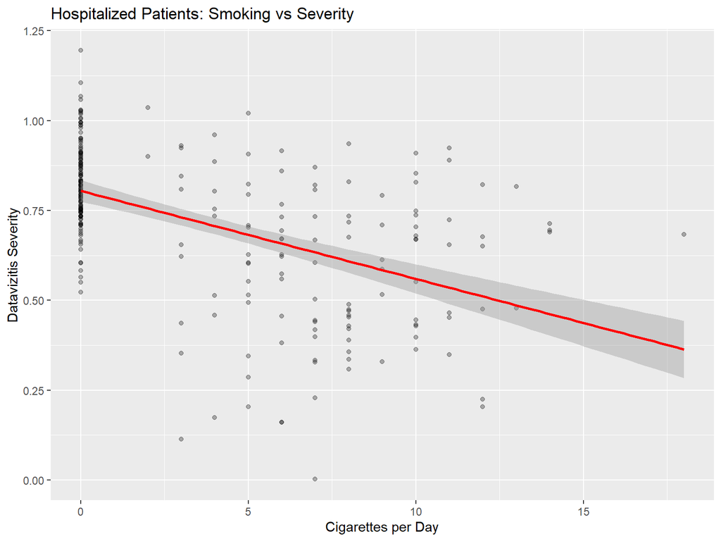

```r
ggplot(datavizitis_dt[hospitalized == "Yes"],
       aes(cigarettes_per_day, datavizitis_severity)) +
  geom_point(alpha = 0.3) +
  geom_smooth(method = "lm", color = "red") +
  labs(title = "Hospitalized Patients: Smoking vs Severity",
       x = "Cigarettes per Day", y = "Datavizitis Severity")
```

### 3. All Individuals

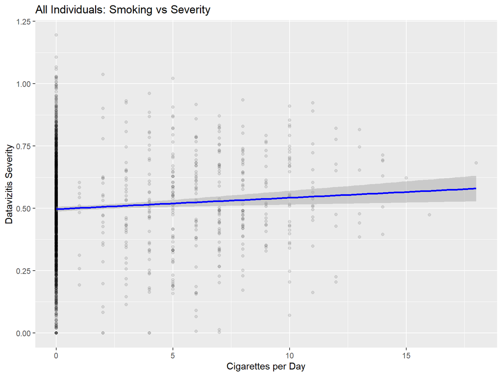

```r
ggplot(datavizitis_dt, aes(cigarettes_per_day, datavizitis_severity)) +
  geom_point(alpha = 0.1) +
  geom_smooth(method = "lm", color = "blue") +
  labs(title = "All Individuals: Smoking vs Severity",
       x = "Cigarettes per Day", y = "Datavizitis Severity")
```

### 4. Combined Visualization

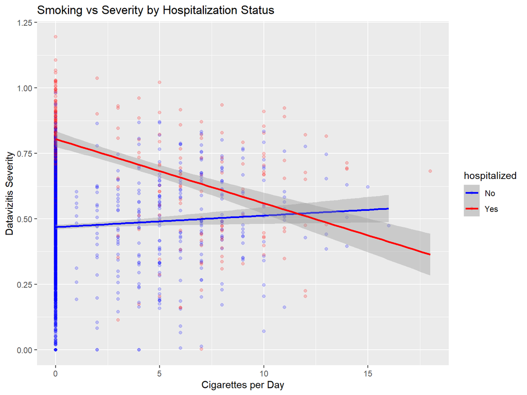

```r
ggplot(datavizitis_dt, aes(cigarettes_per_day, datavizitis_severity, color = hospitalized)) +
  geom_point(alpha = 0.2) +
  geom_smooth(method = "lm") +
  labs(title = "Smoking vs Severity by Hospitalization Status",
       x = "Cigarettes per Day", y = "Datavizitis Severity") +
  scale_color_manual(values = c("Yes" = "red", "No" = "blue"))
```

### 5. Causal Interpretation

The negative association among hospitalized patients may be due to:

- Hospitalization acts as a collider variable
- Both severe symptoms and heavy smoking increase hospitalization likelihood
- This creates a spurious negative correlation in the hospitalized subgroup

Causal diagram:

- Smoking → Hospitalization
- Severity → Hospitalization
- No direct causal link between smoking and severity

## Section 07: Titanic Survival Analysis

### 1. Load and Explore Data

```r
titanic <- fread("../data/titanic.csv")
titanic[, survived := factor(survived, levels = c(0, 1), labels = c("Died", "Survived"))]
titanic[, pclass := factor(pclass, labels = c("First", "Second", "Third"))]

# Overall survival rate
survival_rate <- titanic[, mean(survived == "Survived")]
cat("Overall survival rate:", round(survival_rate * 100, 1), "%\n")
```

```
## Overall survival rate: 38.2 %
```

### 2. Age vs Survival

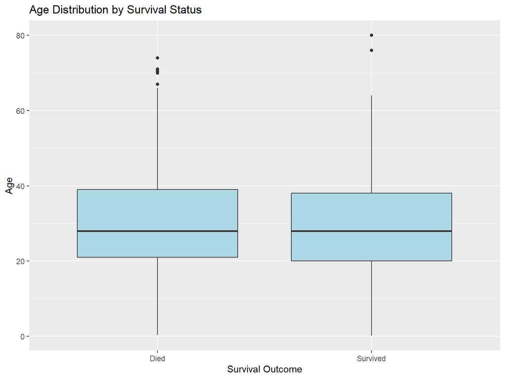

```r
ggplot(titanic, aes(survived, age)) +
  geom_boxplot(fill = "lightblue") +
  labs(x = "Survival Outcome", y = "Age",
       title = "Age Distribution by Survival Status")
```

### 3. Passenger Class vs Survival

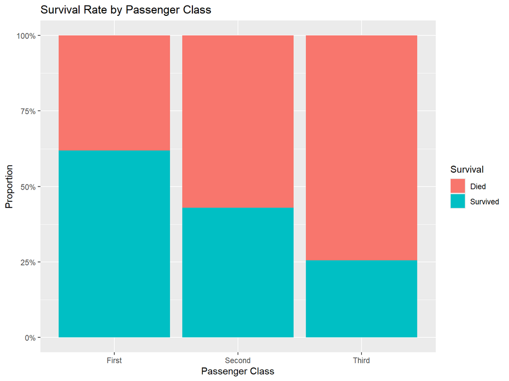

```r
ggplot(titanic, aes(pclass, fill = survived)) +
  geom_bar(position = "fill") +
  labs(x = "Passenger Class", y = "Proportion",
       title = "Survival Rate by Passenger Class",
       fill = "Survival") +
  scale_y_continuous(labels = scales::percent)
```

### 4. Age Distribution by Class

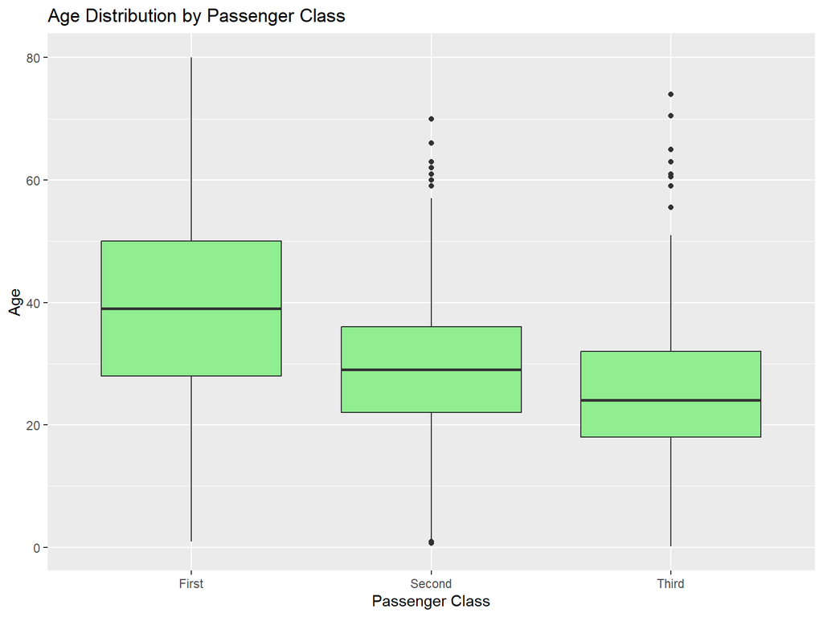

```r
ggplot(titanic, aes(pclass, age)) +
  geom_boxplot(fill = "lightgreen") +
  labs(x = "Passenger Class", y = "Age",
       title = "Age Distribution by Passenger Class")
```

### 5. Combined Analysis

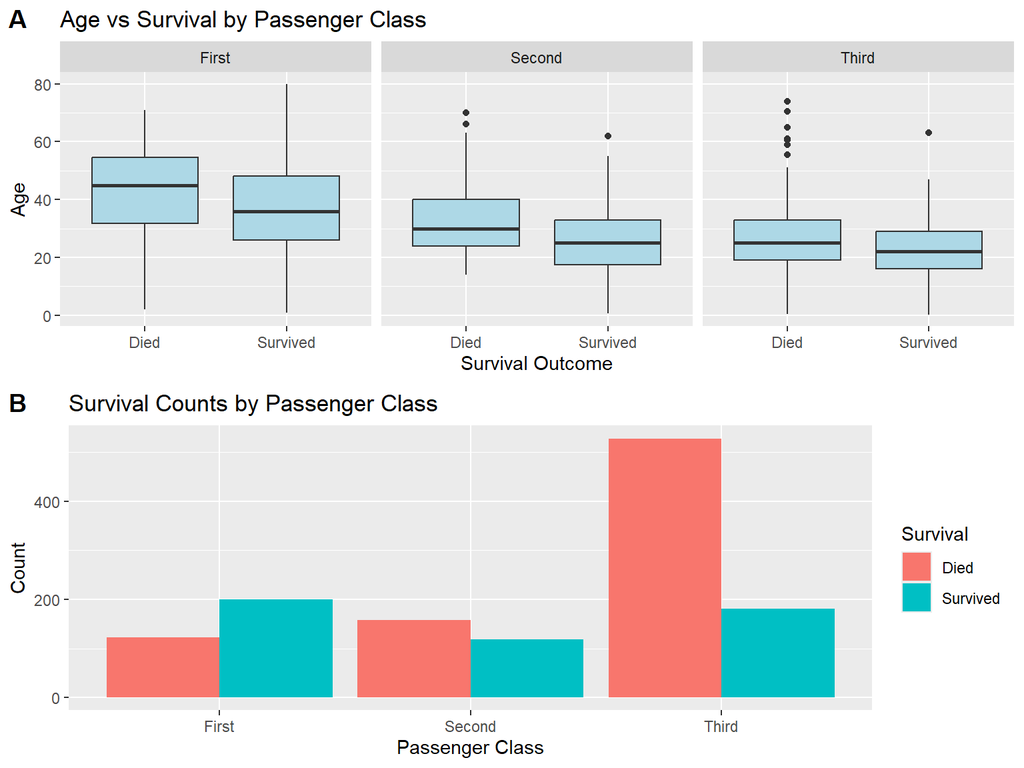

```r
# Age vs Survival by Class
p1 <- ggplot(titanic, aes(survived, age)) +
  geom_boxplot(fill = "lightblue") +
  facet_wrap(~pclass) +
  labs(x = "Survival Outcome", y = "Age",
       title = "Age vs Survival by Passenger Class")

# Survival counts by Class
p2 <- ggplot(titanic, aes(pclass, fill = survived)) +
  geom_bar(position = "dodge") +
  labs(x = "Passenger Class", y = "Count",
       title = "Survival Counts by Passenger Class",
       fill = "Survival")

# Arrange plots
plot_grid(p1, p2, ncol = 1, labels = "AUTO")
```

### 6. Causal Interpretation

Key insights:

- Higher classes had better survival rates (priority access to lifeboats)
- Older passengers were overrepresented in higher classes
- Within each class, younger passengers had better survival rates (rescue priority)

Causal relationships:

- Class → Survival (higher classes had better access to lifeboats)
- Age → Survival (children were prioritized in rescue efforts)
- Class ← Age (wealthier/older passengers in higher classes)

This represents a combination of direct and indirect causal paths.

## Conclusion

This exercise demonstrated how to:

- Identify and visualize third-variable effects
- Recognize Simpson’s paradox in aggregated data
- Create effective visualizations to test hypotheses
- Interpret causal diagrams from observational data